# AppleHealthOtherData

## Overview

This notebook extends the earlier heart-rate project by using Apple Health’s recorded Resting Heart Rate metric directly instead of estimating resting heart rate from the lowest 20 percent of daily heart-rate readings.

That change makes the analysis easier to explain and more aligned with the metric Apple Health itself reports. The workflow still keeps an important rule from the earlier analysis: missing days are not filled in, so the trend is based only on days with observed data.

```python
import xml.etree.ElementTree as ET
import pandas as pd
```

```python
import os
os.getcwd()
```

```
'C:\\Users\\arivu'
```

```python
tree = ET.parse('export.xml')
root = tree.getroot()
```

```python
records = []

for record in root.findall('Record'):
    records.append({
        "type": record.get('type'),
        "startDate": record.get('startDate'),
        "endDate": record.get('endDate'),
        "value": record.get('value'),
        "unit": record.get('unit'),
        "sourceName": record.get('sourceName'),
        "sourceVersion": record.get('sourceVersion')
    })

df = pd.DataFrame(records)
df.head()
```

|  | type | startDate | endDate | value | unit | sourceName | sourceVersion |
| --- | --- | --- | --- | --- | --- | --- | --- |
| 0 | HKQuantityTypeIdentifierDietaryWater | 2020-11-26 19:03:33 -0500 | 2020-11-26 19:03:33 -0500 | 473.176 | mL | FitMenCook | 129 |
| 1 | HKQuantityTypeIdentifierDietaryWater | 2020-11-26 19:03:33 -0500 | 2020-11-26 19:03:33 -0500 | 1892.71 | mL | Simple | 7.2.1.2011241950 |
| 2 | HKQuantityTypeIdentifierDietaryWater | 2020-11-27 17:33:00 -0500 | 2020-11-27 17:33:00 -0500 | 473.176 | mL | Simple | 7.2.1.2011241950 |
| 3 | HKQuantityTypeIdentifierDietaryWater | 2020-11-28 02:12:00 -0500 | 2020-11-28 02:12:00 -0500 | 1182.94 | mL | Simple | 7.2.2.2011251424 |
| 4 | HKQuantityTypeIdentifierDietaryWater | 2020-11-28 14:04:00 -0500 | 2020-11-28 14:04:00 -0500 | 473.176 | mL | Simple | 7.2.2.2011251424 |

```python
df.nunique()
```

```
type                  72
startDate        1652910
endDate          1650660
value             209442
unit                  23
sourceName            19
sourceVersion        230
dtype: int64
```

```python
sorted(df['type'].unique())
```

```
['HKCategoryTypeIdentifierAbdominalCramps',
 'HKCategoryTypeIdentifierAppetiteChanges',
 'HKCategoryTypeIdentifierAppleStandHour',
 'HKCategoryTypeIdentifierAppleWalkingSteadinessEvent',
 'HKCategoryTypeIdentifierAudioExposureEvent',
 'HKCategoryTypeIdentifierBloating',
 'HKCategoryTypeIdentifierConstipation',
 'HKCategoryTypeIdentifierFatigue',
 'HKCategoryTypeIdentifierHandwashingEvent',
 'HKCategoryTypeIdentifierHighHeartRateEvent',
 'HKCategoryTypeIdentifierIntermenstrualBleeding',
 'HKCategoryTypeIdentifierLowCardioFitnessEvent',
 'HKCategoryTypeIdentifierMenstrualFlow',
 'HKCategoryTypeIdentifierMindfulSession',
 'HKCategoryTypeIdentifierMoodChanges',
 'HKCategoryTypeIdentifierSleepAnalysis',
 'HKDataTypeSleepDurationGoal',
 'HKQuantityTypeIdentifierActiveEnergyBurned',
 'HKQuantityTypeIdentifierAppleExerciseTime',
 'HKQuantityTypeIdentifierAppleStandTime',
 'HKQuantityTypeIdentifierAppleWalkingSteadiness',
 'HKQuantityTypeIdentifierBasalEnergyBurned',
 'HKQuantityTypeIdentifierBloodPressureDiastolic',
 'HKQuantityTypeIdentifierBloodPressureSystolic',
 'HKQuantityTypeIdentifierBodyFatPercentage',
 'HKQuantityTypeIdentifierBodyMass',
 'HKQuantityTypeIdentifierBodyMassIndex',
 'HKQuantityTypeIdentifierDietaryCalcium',
 'HKQuantityTypeIdentifierDietaryCarbohydrates',
 'HKQuantityTypeIdentifierDietaryCholesterol',
 'HKQuantityTypeIdentifierDietaryEnergyConsumed',
 'HKQuantityTypeIdentifierDietaryFatMonounsaturated',
 'HKQuantityTypeIdentifierDietaryFatPolyunsaturated',
 'HKQuantityTypeIdentifierDietaryFatSaturated',
 'HKQuantityTypeIdentifierDietaryFatTotal',
 'HKQuantityTypeIdentifierDietaryFiber',
 'HKQuantityTypeIdentifierDietaryIron',
 'HKQuantityTypeIdentifierDietaryPotassium',
 'HKQuantityTypeIdentifierDietaryProtein',
 'HKQuantityTypeIdentifierDietarySodium',
```

[output cut: 17 more lines]

```
 'HKQuantityTypeIdentifierRestingHeartRate',
 'HKQuantityTypeIdentifierRunningPower',
 'HKQuantityTypeIdentifierRunningSpeed',
 'HKQuantityTypeIdentifierSixMinuteWalkTestDistance',
 'HKQuantityTypeIdentifierStairAscentSpeed',
 'HKQuantityTypeIdentifierStairDescentSpeed',
 'HKQuantityTypeIdentifierStepCount',
 'HKQuantityTypeIdentifierTimeInDaylight',
 'HKQuantityTypeIdentifierVO2Max',
 'HKQuantityTypeIdentifierWaistCircumference',
 'HKQuantityTypeIdentifierWalkingAsymmetryPercentage',
 'HKQuantityTypeIdentifierWalkingDoubleSupportPercentage',
 'HKQuantityTypeIdentifierWalkingHeartRateAverage',
 'HKQuantityTypeIdentifierWalkingSpeed',
 'HKQuantityTypeIdentifierWalkingStepLength']
```

## Extracting Resting Heart Rate

The dataset contains 72 Apple Health record types, so the first task is to isolate the Resting Heart Rate records. This step creates a focused dataframe containing only the observations relevant to baseline cardiovascular trend analysis.

A quick preview confirms that the resting-heart-rate data contains timestamps, values, units, source names, and source versions, which makes it possible to study both timing and source-related differences.

```python
rest_hr = df[df['type'] == 'HKQuantityTypeIdentifierRestingHeartRate']
```

```python
rest_hr.head()
```

|  | type | startDate | endDate | value | unit | sourceName | sourceVersion |
| --- | --- | --- | --- | --- | --- | --- | --- |
| 1851108 | HKQuantityTypeIdentifierRestingHeartRate | 2021-02-24 11:20:11 -0500 | 2021-02-24 11:20:38 -0500 | 95 | count/min | Withings | 5040011 |
| 1851109 | HKQuantityTypeIdentifierRestingHeartRate | 2021-02-24 07:45:56 -0500 | 2021-02-24 07:46:18 -0500 | 78 | count/min | Withings | 5040011 |
| 1851110 | HKQuantityTypeIdentifierRestingHeartRate | 2021-02-24 03:00:48 -0500 | 2021-02-24 03:01:10 -0500 | 90 | count/min | Withings | 5040011 |
| 1851111 | HKQuantityTypeIdentifierRestingHeartRate | 2021-02-24 13:55:41 -0500 | 2021-02-24 13:56:03 -0500 | 118 | count/min | Withings | 5040011 |
| 1851112 | HKQuantityTypeIdentifierRestingHeartRate | 2021-02-24 11:29:42 -0500 | 2021-02-24 11:30:11 -0500 | 88 | count/min | Withings | 5040011 |

```python
rest_hr.dtypes
```

```
type             object
startDate        object
endDate          object
value            object
unit             object
sourceName       object
sourceVersion    object
dtype: object
```

```python
rest_hr=rest_hr.copy()
```

## Data Cleaning and Type Conversion

The raw resting-heart-rate records initially load as text values, so the timestamps are converted to datetime and the heart-rate values are converted to numeric format. Timezone information is removed to make date-based aggregation simpler and more consistent within the notebook.

After conversion, invalid values are dropped. This keeps the analysis from being distorted by malformed records while still preserving the original missingness pattern.

```python
rest_hr['startDate'] = pd.to_datetime(rest_hr['startDate'], errors='coerce')
rest_hr['endDate']   = pd.to_datetime(rest_hr['endDate'], errors='coerce')
```

```python
rest_hr['startDate'] = rest_hr['startDate'].dt.tz_localize(None)
rest_hr['endDate']   = rest_hr['endDate'].dt.tz_localize(None)
```

```python
rest_hr['value'] = pd.to_numeric(rest_hr['value'], errors='coerce')
```

## Resting Heart Rate Summary Statistics

The descriptive summary shows the size and spread of the resting-heart-rate dataset. In this notebook, nearly four thousand resting-heart-rate records are available, with a median in the mid-80s and values ranging from 41 to 194 beats per minute.

These summary statistics show that the dataset is large enough for long-term trend analysis, but also variable enough that aggregation is useful before drawing conclusions.

```python
rest_hr['value'].describe()
```

```
count    3989.000000
mean       86.173477
std        14.379353
min        41.000000
25%        77.000000
50%        84.000000
75%        94.000000
max       194.000000
Name: value, dtype: float64
```

```python
rest_hr = rest_hr.dropna(subset=['value', 'startDate'])
```

## Daily and Monthly Aggregation

Apple Health may record multiple resting-heart-rate values on a given day. To create a stable daily series, the notebook takes the median resting heart rate for each day. That daily series is then aggregated to a monthly median to reduce noise and make broader shifts easier to see.

This two-level aggregation keeps the project grounded in Apple’s direct resting-heart-rate metric while still producing a trend series suitable for visualization and change-point analysis.

```python
rest_hr['date'] = rest_hr['startDate'].dt.date

daily_rest_hr = (
    rest_hr.groupby('date')['value']
    .median()
    .reset_index(name='resting_hr')
)

daily_rest_hr['date'] = pd.to_datetime(daily_rest_hr['date'])
```

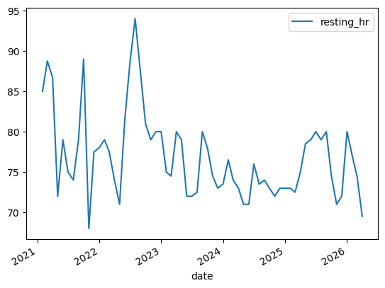

```python
monthly_rest = (
    daily_rest_hr.groupby(daily_rest_hr['date'].dt.to_period('M'))['resting_hr']
    .median()
    .reset_index()
)

monthly_rest['date'] = monthly_rest['date'].dt.to_timestamp()

monthly_rest.plot(x='date', y='resting_hr')
```

```python
daily_rest_hr['year'] = daily_rest_hr['date'].dt.year
daily_rest_hr['day_of_year'] = daily_rest_hr['date'].dt.dayofyear
```

## Yearly Plots and Before/After Metformin View

The notebook then plots the daily resting-heart-rate trend separately for each year, including an average reference line within each yearly chart. This makes it easier to compare how the baseline shifts across calendar years rather than viewing the entire timeline as a single dense line.

A separate before-and-after split around August 2025 is also used to explore the time period when metformin was introduced. This does not prove causation, but it provides a structured way to visually compare earlier and later phases of the resting-heart-rate trend.

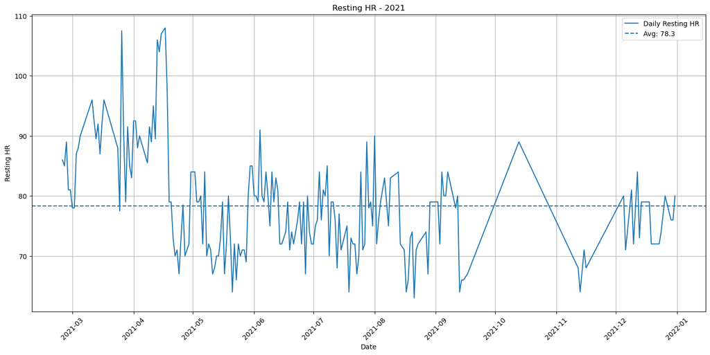

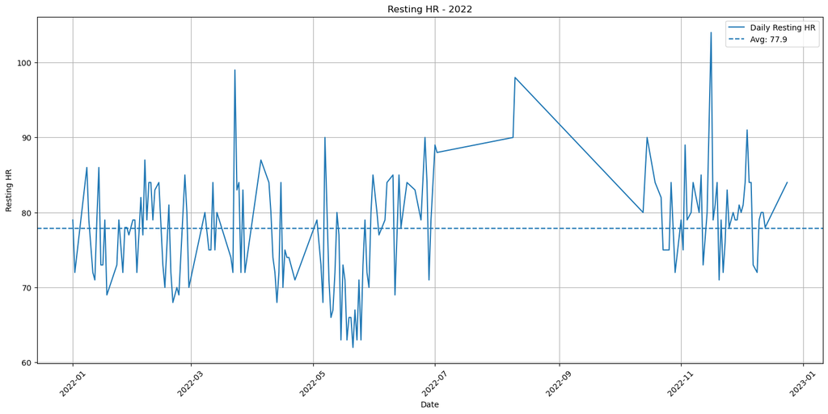

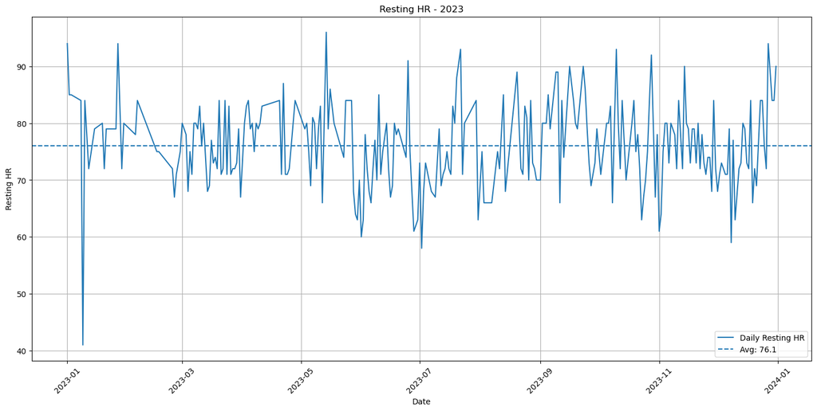

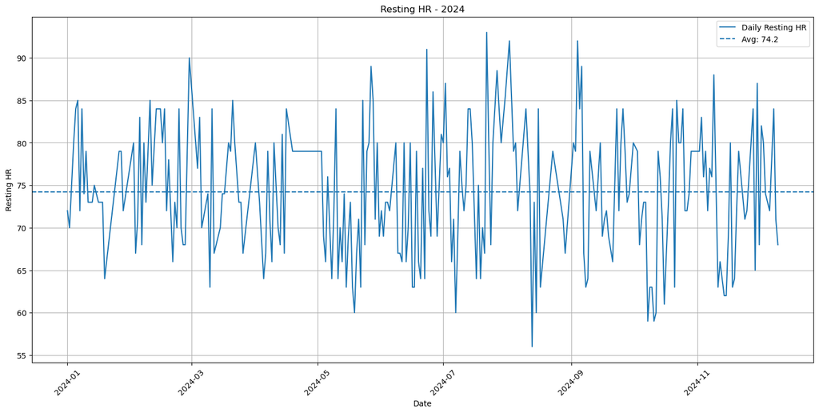

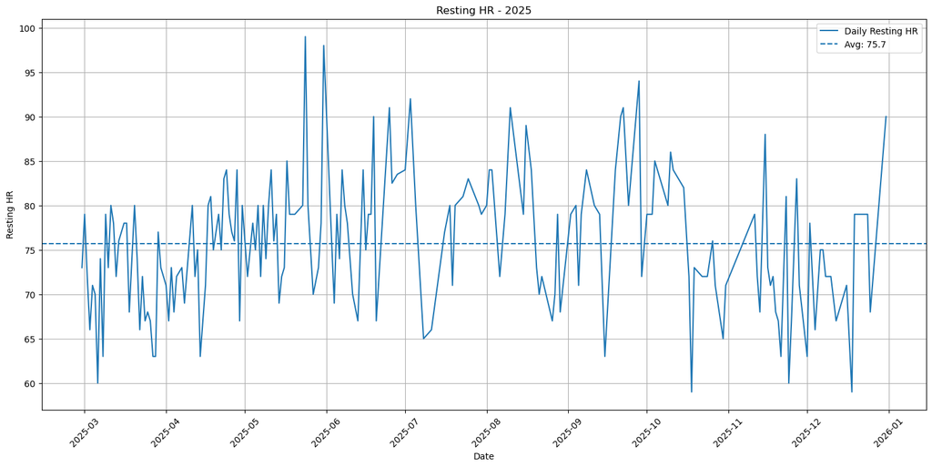

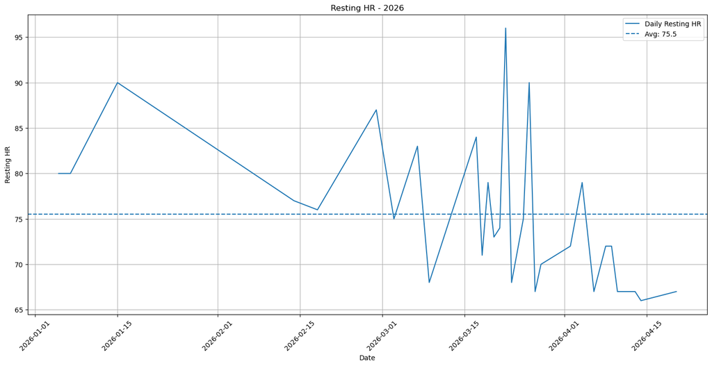

```python
import matplotlib.pyplot as plt

for year, group in daily_rest_hr.groupby('year'):
    plt.figure(figsize=(18, 8))   # ✅ create figure first
    group = group.sort_values('date')
    avg = group['resting_hr'].mean()

    plt.plot(group['date'], group['resting_hr'], label='Daily Resting HR')
    plt.axhline(avg, linestyle='--', label=f'Avg: {avg:.1f}')

    plt.grid(True)
    plt.xticks(rotation=45)

    plt.title(f"Resting HR - {year}")
    plt.xlabel("Date")
    plt.ylabel("Resting HR")
    plt.legend()

    plt.show()
```

```python
cutoff = pd.to_datetime("2025-08-01")
```

```python
before_metformin = daily_rest_hr[daily_rest_hr['date'] < cutoff]
after_metformin  = daily_rest_hr[daily_rest_hr['date'] >= cutoff]
```

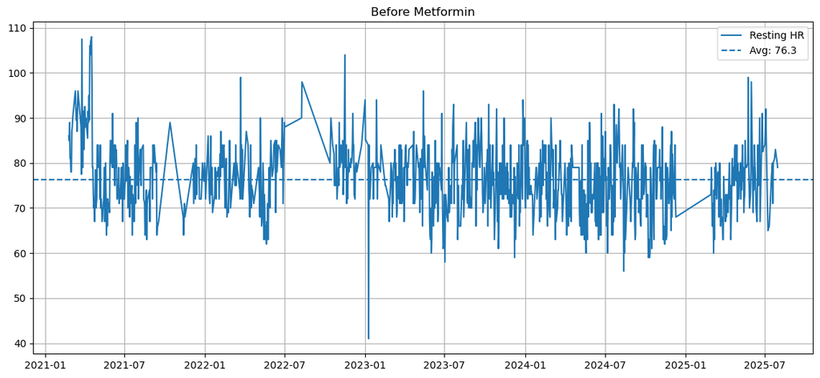

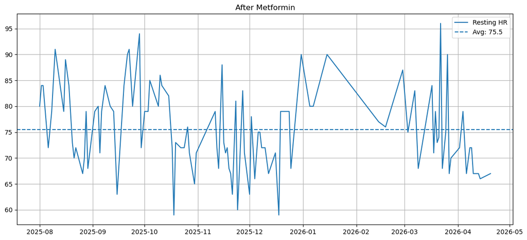

```python
import matplotlib.pyplot as plt

for label, data in {
    "Before Metformin": before_metformin,
    "After Metformin": after_metformin
}.items():

    plt.figure(figsize=(14,6))

    data = data.sort_values('date')
    avg = data['resting_hr'].mean()

    plt.plot(data['date'], data['resting_hr'], label='Resting HR')
    plt.axhline(avg, linestyle='--', label=f'Avg: {avg:.1f}')

    plt.title(label)
    plt.legend()
    plt.grid(True)
    plt.savefig(f"{label.replace(' ', '_')}.png", bbox_inches='tight')
    plt.show()
```

## Hourly Resting Heart Rate Pattern

The analysis also extracts the hour from each resting-heart-rate timestamp and groups the observations by hour of day. This provides a simple view of how recorded resting heart rate varies across a 24-hour cycle.

This helps add time-of-day context to the project. Lower values are generally more likely during sleep or low-activity periods, while higher recorded resting values may appear during waking hours depending on how Apple Health captured the metric.

```python
rest_hr['hour'] = rest_hr['startDate'].dt.hour
```

```python
hourly = rest_hr.groupby('hour')['value'].mean().reset_index()
```

```python
import os
os.makedirs("images", exist_ok=True)
```

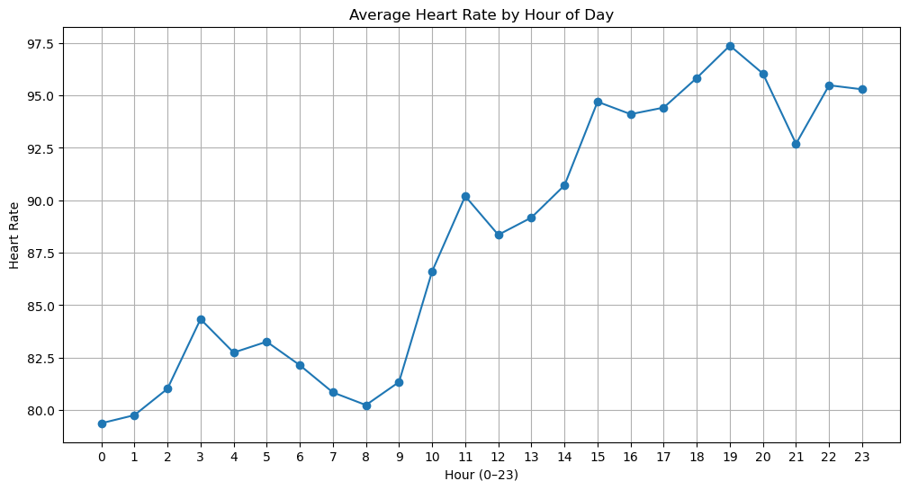

```python
import matplotlib.pyplot as plt

plt.figure(figsize=(12,6))
plt.plot(hourly['hour'], hourly['value'], marker='o')

plt.title("Average Heart Rate by Hour of Day")
plt.xlabel("Hour (0–23)")
plt.ylabel("Heart Rate")

plt.grid(True)
plt.xticks(range(0,24))

plt.savefig("images/hourly_hr.png", bbox_inches='tight')  # optional
plt.show()
```

## Change Point Detection

To identify when the long-term resting-heart-rate baseline shifted, the monthly series is analyzed using rolling averages before and after each point. The absolute difference between those windows is used as a change score.

A minimum spacing rule of about 180 days is then used when selecting major change points. This prevents the chart from marking multiple nearby dates that represent the same local transition.

```python
cp = monthly_rest.copy().sort_values('date')
cp = cp.dropna(subset=['resting_hr'])

cp.head()
```

|  | date | resting_hr |
| --- | --- | --- |
| 0 | 2021-02-01 | 85.00 |
| 1 | 2021-03-01 | 88.75 |
| 2 | 2021-04-01 | 86.75 |
| 3 | 2021-05-01 | 72.00 |
| 4 | 2021-06-01 | 79.00 |

```python
cp['prev_3'] = cp['resting_hr'].rolling(3).mean().shift(1)
cp['next_3'] = cp['resting_hr'].rolling(3).mean().shift(-2)

cp['change_score'] = (cp['next_3'] - cp['prev_3']).abs()
```

```python
cp_sorted = cp.sort_values('change_score', ascending=False)
```

```python
min_gap = 180

selected = []
for _, row in cp_sorted.iterrows():
    if all(abs((row['date'] - s['date']).days) > min_gap for s in selected):
        selected.append(row)
    if len(selected) == 3:
        break

top_points = pd.DataFrame(selected)
```

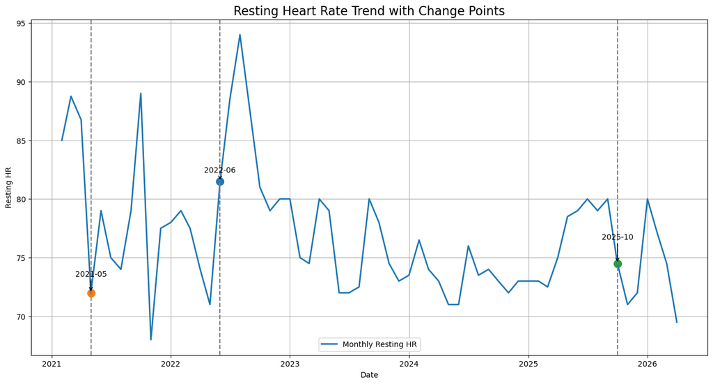

```python
import matplotlib.pyplot as plt
import os

# ensure folder exists
os.makedirs("images", exist_ok=True)

plt.figure(figsize=(16,8))

# main trend
plt.plot(cp['date'], cp['resting_hr'], linewidth=2, label='Monthly Resting HR')

# plot change points with annotations
for i, (_, row) in enumerate(top_points.iterrows()):
    plt.axvline(row['date'], linestyle='--', linewidth=1.5, color='gray')
    plt.scatter(row['date'], row['resting_hr'], s=100)

    plt.annotate(
        row['date'].strftime('%Y-%m'),
        (row['date'], row['resting_hr']),
        textcoords="offset points",
        xytext=(0, 12 + i*10),   # stagger labels
        ha='center',
        fontsize=10,
        arrowprops=dict(arrowstyle='->')
    )

# labels and styling
plt.title("Resting Heart Rate Trend with Change Points", fontsize=16)
plt.xlabel("Date")
plt.ylabel("Resting HR")

plt.grid(True)
plt.legend()

# save image
plt.savefig("images/final_change_points.png", bbox_inches='tight')

# show plot
plt.show()
```

## Conclusion

This notebook shows a stronger version of the earlier Apple Health heart-rate analysis by switching from an estimated resting-heart-rate proxy to Apple Health’s direct Resting Heart Rate metric. That makes the methodology simpler, more interpretable, and more defensible.

The cleaned resting-heart-rate data was aggregated into daily and monthly series, visualized by year, compared across a metformin-related time split, examined by hour of day, and analyzed with change-point detection. Together, these steps suggest that baseline resting heart rate changed over time in phases rather than through one abrupt jump.

Overall, this project demonstrates a practical end-to-end workflow for wearable health data: filtering mixed health records, cleaning timestamps and numeric values, preserving missingness correctly, building interpretable trend summaries, and using visual plus statistical methods to detect structural changes in a longitudinal physiological metric.